# Анализ COVID 19_3

```python
import pandas as pd
import numpy as np

import matplotlib.pyplot as plt
```

## Данные для анализа

https://www.kaggle.com/sudalairajkumar/novel-corona-virus-2019-dataset#covid_19_data.csv

Прочитаем ежеденевно обновляемые данные из ссылки и загрузим себе.

```python
COVID_ = pd.read_csv('covid_19_data.csv')
COVID_.head(20)
```

|  | SNo | ObservationDate | Province/State | Country/Region | Last Update | Confirmed | Deaths | Recovered |
| --- | --- | --- | --- | --- | --- | --- | --- | --- |
| 0 | 1 | 01/22/2020 | Anhui | Mainland China | 1/22/2020 17:00 | 1.0 | 0.0 | 0.0 |
| 1 | 2 | 01/22/2020 | Beijing | Mainland China | 1/22/2020 17:00 | 14.0 | 0.0 | 0.0 |
| 2 | 3 | 01/22/2020 | Chongqing | Mainland China | 1/22/2020 17:00 | 6.0 | 0.0 | 0.0 |
| 3 | 4 | 01/22/2020 | Fujian | Mainland China | 1/22/2020 17:00 | 1.0 | 0.0 | 0.0 |
| 4 | 5 | 01/22/2020 | Gansu | Mainland China | 1/22/2020 17:00 | 0.0 | 0.0 | 0.0 |
| 5 | 6 | 01/22/2020 | Guangdong | Mainland China | 1/22/2020 17:00 | 26.0 | 0.0 | 0.0 |
| 6 | 7 | 01/22/2020 | Guangxi | Mainland China | 1/22/2020 17:00 | 2.0 | 0.0 | 0.0 |
| 7 | 8 | 01/22/2020 | Guizhou | Mainland China | 1/22/2020 17:00 | 1.0 | 0.0 | 0.0 |
| 8 | 9 | 01/22/2020 | Hainan | Mainland China | 1/22/2020 17:00 | 4.0 | 0.0 | 0.0 |
| 9 | 10 | 01/22/2020 | Hebei | Mainland China | 1/22/2020 17:00 | 1.0 | 0.0 | 0.0 |
| 10 | 11 | 01/22/2020 | Heilongjiang | Mainland China | 1/22/2020 17:00 | 0.0 | 0.0 | 0.0 |
| 11 | 12 | 01/22/2020 | Henan | Mainland China | 1/22/2020 17:00 | 5.0 | 0.0 | 0.0 |
| 12 | 13 | 01/22/2020 | Hong Kong | Hong Kong | 1/22/2020 17:00 | 0.0 | 0.0 | 0.0 |
| 13 | 14 | 01/22/2020 | Hubei | Mainland China | 1/22/2020 17:00 | 444.0 | 17.0 | 28.0 |
| 14 | 15 | 01/22/2020 | Hunan | Mainland China | 1/22/2020 17:00 | 4.0 | 0.0 | 0.0 |
| 15 | 16 | 01/22/2020 | Inner Mongolia | Mainland China | 1/22/2020 17:00 | 0.0 | 0.0 | 0.0 |
| 16 | 17 | 01/22/2020 | Jiangsu | Mainland China | 1/22/2020 17:00 | 1.0 | 0.0 | 0.0 |
| 17 | 18 | 01/22/2020 | Jiangxi | Mainland China | 1/22/2020 17:00 | 2.0 | 0.0 | 0.0 |
| 18 | 19 | 01/22/2020 | Jilin | Mainland China | 1/22/2020 17:00 | 0.0 | 0.0 | 0.0 |
| 19 | 20 | 01/22/2020 | Liaoning | Mainland China | 1/22/2020 17:00 | 2.0 | 0.0 | 0.0 |

```python
COVID_.tail()
```

|  | SNo | ObservationDate | Province/State | Country/Region | Last Update | Confirmed | Deaths | Recovered |
| --- | --- | --- | --- | --- | --- | --- | --- | --- |
| 35197 | 35198 | 06/04/2020 | Zacatecas | Mexico | 2020-06-05 02:33:06 | 341.0 | 41.0 | 219.0 |
| 35198 | 35199 | 06/04/2020 | Zakarpattia Oblast | Ukraine | 2020-06-05 02:33:06 | 1257.0 | 28.0 | 524.0 |
| 35199 | 35200 | 06/04/2020 | Zaporizhia Oblast | Ukraine | 2020-06-05 02:33:06 | 469.0 | 14.0 | 269.0 |
| 35200 | 35201 | 06/04/2020 | Zhejiang | Mainland China | 2020-06-05 02:33:06 | 1268.0 | 1.0 | 1267.0 |
| 35201 | 35202 | 06/04/2020 | Zhytomyr Oblast | Ukraine | 2020-06-05 02:33:06 | 833.0 | 14.0 | 474.0 |

Выносим дату отдельным столбцом и делаем копии

```python
COVID = COVID_.copy()
COVID_['Data']= pd.to_datetime(COVID_['ObservationDate']).dt.date
COVID['Data']= pd.to_datetime(COVID['ObservationDate']).dt.date
```

Группируем по странам (без провинций) и дате измерения

```python
COVID = COVID.groupby(['Data','Country/Region'])['Confirmed','Deaths','Recovered'].sum()
```

```python
COVID.head(30)
```

| Data | Country/Region | Confirmed | Deaths | Recovered |
| --- | --- | --- | --- | --- |
| 2020-01-22 | Hong Kong | 0.0 | 0.0 | 0.0 |
|  | Japan | 2.0 | 0.0 | 0.0 |
|  | Macau | 1.0 | 0.0 | 0.0 |
|  | Mainland China | 547.0 | 17.0 | 28.0 |
|  | South Korea | 1.0 | 0.0 | 0.0 |
|  | Taiwan | 1.0 | 0.0 | 0.0 |
|  | Thailand | 2.0 | 0.0 | 0.0 |
|  | US | 1.0 | 0.0 | 0.0 |
| 2020-01-23 | Australia | 0.0 | 0.0 | 0.0 |
|  | Brazil | 0.0 | 0.0 | 0.0 |
|  | Colombia | 0.0 | 0.0 | 0.0 |
|  | Hong Kong | 2.0 | 0.0 | 0.0 |
|  | Japan | 1.0 | 0.0 | 0.0 |
|  | Macau | 2.0 | 0.0 | 0.0 |
|  | Mainland China | 639.0 | 18.0 | 30.0 |
|  | Malaysia | 0.0 | 0.0 | 0.0 |
|  | Mexico | 0.0 | 0.0 | 0.0 |
|  | Philippines | 0.0 | 0.0 | 0.0 |
|  | Singapore | 1.0 | 0.0 | 0.0 |
|  | South Korea | 1.0 | 0.0 | 0.0 |
|  | Taiwan | 1.0 | 0.0 | 0.0 |
|  | Thailand | 3.0 | 0.0 | 0.0 |
|  | US | 1.0 | 0.0 | 0.0 |
|  | Vietnam | 2.0 | 0.0 | 0.0 |
| 2020-01-24 | France | 2.0 | 0.0 | 0.0 |
|  | Hong Kong | 2.0 | 0.0 | 0.0 |
|  | Japan | 2.0 | 0.0 | 0.0 |
|  | Macau | 2.0 | 0.0 | 0.0 |
|  | Mainland China | 916.0 | 26.0 | 36.0 |
|  | Singapore | 3.0 | 0.0 | 0.0 |

Нарисуем для КИтая

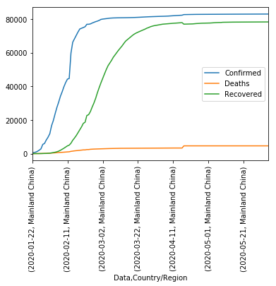

```python
COVID.loc[COVID.index.get_level_values( 'Country/Region')=='Mainland China', ['Confirmed','Deaths','Recovered']].plot()
plt.xticks(label = COVID.index.get_level_values('Data'), rotation=90)

plt.show()
```

Есть какие-то странные места в феврале

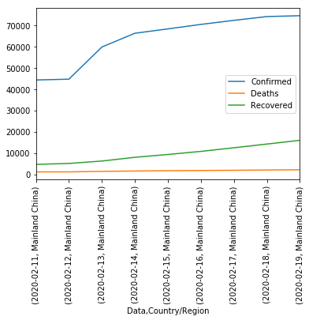

```python
COVID.loc[((COVID.index.get_level_values( 'Country/Region')=='Mainland China') & (COVID.index.get_level_values( 'Data') > pd.to_datetime('2020-02-10'))& (COVID.index.get_level_values( 'Data') < pd.to_datetime('2020-02-20'))), ['Confirmed','Deaths','Recovered']].plot()
plt.xticks(label = COVID.index.get_level_values('Data'), rotation=90)

plt.show()
```

Посмотрим на них в цифрах

```python
COVID_.loc[( (COVID_[ 'Country/Region']=='Mainland China') & (COVID_['Data'] > pd.to_datetime('2020-02-11'))& (COVID_['Data'] < pd.to_datetime('2020-02-14'))), :].head(50)
```

|  | SNo | ObservationDate | Province/State | Country/Region | Last Update | Confirmed | Deaths | Recovered | Data |
| --- | --- | --- | --- | --- | --- | --- | --- | --- | --- |
| 1268 | 1269 | 02/12/2020 | Hubei | Mainland China | 2020-02-12T14:13:08 | 33366.0 | 1068.0 | 2686.0 | 2020-02-12 |
| 1269 | 1270 | 02/12/2020 | Guangdong | Mainland China | 2020-02-12T12:23:09 | 1219.0 | 1.0 | 275.0 | 2020-02-12 |
| 1270 | 1271 | 02/12/2020 | Henan | Mainland China | 2020-02-12T14:13:08 | 1135.0 | 8.0 | 246.0 | 2020-02-12 |
| 1271 | 1272 | 02/12/2020 | Zhejiang | Mainland China | 2020-02-12T10:13:20 | 1131.0 | 0.0 | 321.0 | 2020-02-12 |
| 1272 | 1273 | 02/12/2020 | Hunan | Mainland China | 2020-02-12T12:43:03 | 946.0 | 2.0 | 304.0 | 2020-02-12 |
| 1273 | 1274 | 02/12/2020 | Anhui | Mainland China | 2020-02-12T10:13:20 | 889.0 | 4.0 | 127.0 | 2020-02-12 |
| 1274 | 1275 | 02/12/2020 | Jiangxi | Mainland China | 2020-02-12T01:23:06 | 844.0 | 1.0 | 152.0 | 2020-02-12 |
| 1275 | 1276 | 02/12/2020 | Jiangsu | Mainland China | 2020-02-12T14:13:08 | 543.0 | 0.0 | 125.0 | 2020-02-12 |
| 1276 | 1277 | 02/12/2020 | Chongqing | Mainland China | 2020-02-12T23:13:08 | 518.0 | 3.0 | 102.0 | 2020-02-12 |
| 1277 | 1278 | 02/12/2020 | Shandong | Mainland China | 2020-02-12T11:13:05 | 497.0 | 2.0 | 92.0 | 2020-02-12 |
| 1278 | 1279 | 02/12/2020 | Sichuan | Mainland China | 2020-02-12T12:43:03 | 436.0 | 1.0 | 92.0 | 2020-02-12 |
| 1279 | 1280 | 02/12/2020 | Heilongjiang | Mainland China | 2020-02-12T14:13:08 | 378.0 | 8.0 | 31.0 | 2020-02-12 |
| 1280 | 1281 | 02/12/2020 | Beijing | Mainland China | 2020-02-12T02:43:03 | 352.0 | 3.0 | 56.0 | 2020-02-12 |
| 1281 | 1282 | 02/12/2020 | Shanghai | Mainland China | 2020-02-12T06:23:08 | 311.0 | 1.0 | 57.0 | 2020-02-12 |
| 1282 | 1283 | 02/12/2020 | Fujian | Mainland China | 2020-02-12T11:53:02 | 272.0 | 0.0 | 53.0 | 2020-02-12 |
| 1283 | 1284 | 02/12/2020 | Hebei | Mainland China | 2020-02-12T11:13:05 | 251.0 | 2.0 | 54.0 | 2020-02-12 |
| 1284 | 1285 | 02/12/2020 | Shaanxi | Mainland China | 2020-02-12T11:13:05 | 225.0 | 0.0 | 43.0 | 2020-02-12 |
| 1285 | 1286 | 02/12/2020 | Guangxi | Mainland China | 2020-02-12T15:03:05 | 222.0 | 1.0 | 32.0 | 2020-02-12 |
| 1287 | 1288 | 02/12/2020 | Hainan | Mainland China | 2020-02-12T17:03:03 | 157.0 | 4.0 | 27.0 | 2020-02-12 |
| 1288 | 1289 | 02/12/2020 | Yunnan | Mainland China | 2020-02-12T14:13:08 | 154.0 | 0.0 | 26.0 | 2020-02-12 |
| 1289 | 1290 | 02/12/2020 | Guizhou | Mainland China | 2020-02-12T09:43:02 | 133.0 | 1.0 | 18.0 | 2020-02-12 |
| 1290 | 1291 | 02/12/2020 | Shanxi | Mainland China | 2020-02-12T23:03:02 | 126.0 | 0.0 | 33.0 | 2020-02-12 |
| 1291 | 1292 | 02/12/2020 | Liaoning | Mainland China | 2020-02-12T13:33:02 | 116.0 | 1.0 | 20.0 | 2020-02-12 |
| 1292 | 1293 | 02/12/2020 | Tianjin | Mainland China | 2020-02-12T15:03:05 | 112.0 | 2.0 | 11.0 | 2020-02-12 |
| 1293 | 1294 | 02/12/2020 | Gansu | Mainland China | 2020-02-12T23:23:01 | 87.0 | 2.0 | 31.0 | 2020-02-12 |
| 1294 | 1295 | 02/12/2020 | Jilin | Mainland China | 2020-02-12T14:13:08 | 83.0 | 1.0 | 22.0 | 2020-02-12 |
| 1295 | 1296 | 02/12/2020 | Inner Mongolia | Mainland China | 2020-02-12T11:13:05 | 60.0 | 0.0 | 6.0 | 2020-02-12 |
| 1296 | 1297 | 02/12/2020 | Xinjiang | Mainland China | 2020-02-12T01:43:02 | 59.0 | 0.0 | 3.0 | 2020-02-12 |
| 1297 | 1298 | 02/12/2020 | Ningxia | Mainland China | 2020-02-12T11:13:05 | 58.0 | 0.0 | 24.0 | 2020-02-12 |
| 1303 | 1304 | 02/12/2020 | Qinghai | Mainland China | 2020-02-12T08:03:06 | 18.0 | 0.0 | 9.0 | 2020-02-12 |
| 1330 | 1331 | 02/12/2020 | Tibet | Mainland China | 2020-02-12T06:43:02 | 1.0 | 0.0 | 1.0 | 2020-02-12 |
| 1341 | 1342 | 02/13/2020 | Hubei | Mainland China | 2020-02-13T14:13:06 | 48206.0 | 1310.0 | 3459.0 | 2020-02-13 |
| 1342 | 1343 | 02/13/2020 | Guangdong | Mainland China | 2020-02-13T13:33:01 | 1241.0 | 2.0 | 314.0 | 2020-02-13 |
| 1343 | 1344 | 02/13/2020 | Henan | Mainland China | 2020-02-13T14:53:02 | 1169.0 | 10.0 | 296.0 | 2020-02-13 |
| 1344 | 1345 | 02/13/2020 | Zhejiang | Mainland China | 2020-02-13T14:13:06 | 1145.0 | 0.0 | 360.0 | 2020-02-13 |
| 1345 | 1346 | 02/13/2020 | Hunan | Mainland China | 2020-02-13T11:53:02 | 968.0 | 2.0 | 339.0 | 2020-02-13 |
| 1346 | 1347 | 02/13/2020 | Anhui | Mainland China | 2020-02-13T13:33:01 | 910.0 | 5.0 | 157.0 | 2020-02-13 |
| 1347 | 1348 | 02/13/2020 | Jiangxi | Mainland China | 2020-02-13T01:13:08 | 872.0 | 1.0 | 170.0 | 2020-02-13 |
| 1348 | 1349 | 02/13/2020 | Jiangsu | Mainland China | 2020-02-13T10:33:23 | 570.0 | 0.0 | 139.0 | 2020-02-13 |
| 1349 | 1350 | 02/13/2020 | Chongqing | Mainland China | 2020-02-13T23:23:05 | 529.0 | 4.0 | 128.0 | 2020-02-13 |
| 1350 | 1351 | 02/13/2020 | Shandong | Mainland China | 2020-02-13T13:33:01 | 509.0 | 2.0 | 105.0 | 2020-02-13 |
| 1351 | 1352 | 02/13/2020 | Sichuan | Mainland China | 2020-02-13T13:33:01 | 451.0 | 1.0 | 104.0 | 2020-02-13 |
| 1352 | 1353 | 02/13/2020 | Heilongjiang | Mainland China | 2020-02-13T12:13:06 | 395.0 | 9.0 | 33.0 | 2020-02-13 |
| 1353 | 1354 | 02/13/2020 | Beijing | Mainland China | 2020-02-13T14:13:06 | 366.0 | 3.0 | 69.0 | 2020-02-13 |
| 1354 | 1355 | 02/13/2020 | Shanghai | Mainland China | 2020-02-13T06:13:15 | 315.0 | 1.0 | 62.0 | 2020-02-13 |
| 1355 | 1356 | 02/13/2020 | Fujian | Mainland China | 2020-02-13T10:33:23 | 279.0 | 0.0 | 57.0 | 2020-02-13 |
| 1356 | 1357 | 02/13/2020 | Hebei | Mainland China | 2020-02-13T10:33:23 | 265.0 | 3.0 | 68.0 | 2020-02-13 |
| 1357 | 1358 | 02/13/2020 | Shaanxi | Mainland China | 2020-02-13T10:33:23 | 229.0 | 0.0 | 46.0 | 2020-02-13 |
| 1358 | 1359 | 02/13/2020 | Guangxi | Mainland China | 2020-02-13T00:23:10 | 222.0 | 2.0 | 33.0 | 2020-02-13 |
| 1360 | 1361 | 02/13/2020 | Hainan | Mainland China | 2020-02-13T10:43:03 | 157.0 | 4.0 | 30.0 | 2020-02-13 |

Пока нет дополнительной информации не скажешь, что происходит (а это пояснение https://www.interfax.ru/world/695138 - стали включать клинический диагноз) - пожоже нужно разделить модель на до и после.

```python
COVID.head(20)
```

| Data | Country/Region | Confirmed | Deaths | Recovered |
| --- | --- | --- | --- | --- |
| 2020-01-22 | Hong Kong | 0.0 | 0.0 | 0.0 |
|  | Japan | 2.0 | 0.0 | 0.0 |
|  | Macau | 1.0 | 0.0 | 0.0 |
|  | Mainland China | 547.0 | 17.0 | 28.0 |
|  | South Korea | 1.0 | 0.0 | 0.0 |
|  | Taiwan | 1.0 | 0.0 | 0.0 |
|  | Thailand | 2.0 | 0.0 | 0.0 |
|  | US | 1.0 | 0.0 | 0.0 |
| 2020-01-23 | Australia | 0.0 | 0.0 | 0.0 |
|  | Brazil | 0.0 | 0.0 | 0.0 |
|  | Colombia | 0.0 | 0.0 | 0.0 |
|  | Hong Kong | 2.0 | 0.0 | 0.0 |
|  | Japan | 1.0 | 0.0 | 0.0 |
|  | Macau | 2.0 | 0.0 | 0.0 |
|  | Mainland China | 639.0 | 18.0 | 30.0 |
|  | Malaysia | 0.0 | 0.0 | 0.0 |
|  | Mexico | 0.0 | 0.0 | 0.0 |
|  | Philippines | 0.0 | 0.0 | 0.0 |
|  | Singapore | 1.0 | 0.0 | 0.0 |
|  | South Korea | 1.0 | 0.0 | 0.0 |

Сделаем первые разности (производную)

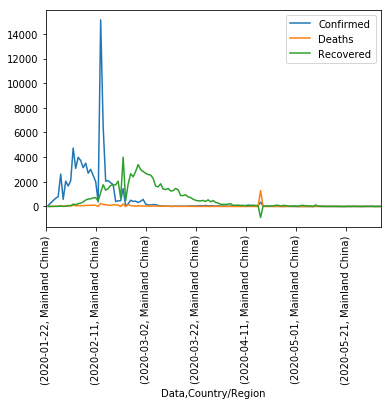

```python
COVID.loc[COVID.index.get_level_values( 'Country/Region')=='Mainland China', ['Confirmed','Deaths','Recovered']].diff(1).plot()
plt.xticks(label = COVID.index.get_level_values('Data'), rotation=90)

plt.show()
```

Опять большой пик - нужен дополнительный анализ

Посмотрим только на выздоровление (так оптимистичней:))

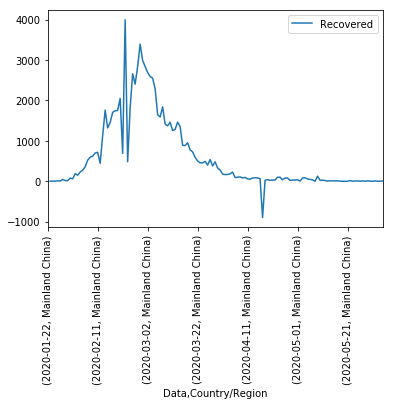

```python
COVID.loc[COVID.index.get_level_values( 'Country/Region')=='Mainland China', ['Recovered']].diff(1).plot()
plt.xticks(label = COVID.loc[COVID.index.get_level_values( 'Country/Region')=='Mainland China', ['Recovered']].diff(1).values, rotation=90)

plt.show()
```

Странный ход данных сохранился - будем разбираться, что происходит

## Построим признаки

1) Первая разность (производная ряда) - разница с(t)-c(t-1) по всем t

```python
X1 = COVID.loc[COVID.index.get_level_values( 'Country/Region')=='Mainland China', ['Confirmed','Deaths','Recovered']].diff(1).values
X1[0,:] = 0.0
```

Делаем исправление "десятки Си" - не очень корректно, зато просто и не нарушает логики явления. Однако помним, что это место, с которым следует разбираться для других стран (ВОЗ меняла правила сбора статистики несколько раз)

```python
ind= np.where(X1[:,2]<-100)
X1[ind[0],2] = (X1[ind[0]-1,2]+X1[ind[0]+1,2])/2
```

2) Сами значения элементов ряда по времени

```python
X2 = COVID.loc[COVID.index.get_level_values( 'Country/Region')=='Mainland China', ['Confirmed','Deaths','Recovered']].values
```

```python
X1.shape
```

```
(135, 3)
```

```python
X2.shape
```

```
(135, 3)
```

3) Добавим признаков по календарю

```python
X3 = COVID.iloc[COVID.index.get_level_values( 'Country/Region')=='Mainland China'].index.get_level_values( 'Data')
```

```python
X3
```

```
Index([2020-01-22, 2020-01-23, 2020-01-24, 2020-01-25, 2020-01-26, 2020-01-27,
       2020-01-28, 2020-01-29, 2020-01-30, 2020-01-31,
       ...
       2020-05-26, 2020-05-27, 2020-05-28, 2020-05-29, 2020-05-30, 2020-05-31,
       2020-06-01, 2020-06-02, 2020-06-03, 2020-06-04],
      dtype='object', name='Data', length=135)
```

3.1) - день недели по счету

3.2) - день от начала статистики в текущей таблице (для Китая - 1-й день карантина(возможно), для других стран следует посмотреть на первый не 0-й экземпляр по 'Confirmed') - строим как "текущий день года" - "первый день от начала отсчета данных по номеру в году"

```python
X3_1 = pd.to_datetime(X3).dayofweek
X3_2 = pd.to_datetime(X3).dayofyear -  pd.to_datetime(X3[0]).dayofyear
```

```python
X3_2
```

```
Int64Index([  0,   1,   2,   3,   4,   5,   6,   7,   8,   9,
            ...
            125, 126, 127, 128, 129, 130, 131, 132, 133, 134],
           dtype='int64', name='Data', length=135)
```

Собирем все в кучу

```python
XX = np.concatenate([X1,X2], axis= 1)
```

```python
XX = np.concatenate([XX,np.array(X3_1).reshape((X1.shape[0],1))], axis= 1)
```

```python
XX = np.concatenate([XX,np.array(X3_2).reshape((X1.shape[0],1))], axis= 1)
```

```python
XX.shape
```

```
(135, 8)
```

Таблица признаков для Китая

```python
COVID_Data = pd.DataFrame(data= XX, index= X3)
```

```python
COVID_Data.head()
```

| Data | 0 | 1 | 2 | 3 | 4 | 5 | 6 | 7 |
| --- | --- | --- | --- | --- | --- | --- | --- | --- |
| 2020-01-22 | 0.0 | 0.0 | 0.0 | 547.0 | 17.0 | 28.0 | 2.0 | 0.0 |
| 2020-01-23 | 92.0 | 1.0 | 2.0 | 639.0 | 18.0 | 30.0 | 3.0 | 1.0 |
| 2020-01-24 | 277.0 | 8.0 | 6.0 | 916.0 | 26.0 | 36.0 | 4.0 | 2.0 |
| 2020-01-25 | 483.0 | 16.0 | 3.0 | 1399.0 | 42.0 | 39.0 | 5.0 | 3.0 |
| 2020-01-26 | 663.0 | 14.0 | 10.0 | 2062.0 | 56.0 | 49.0 | 6.0 | 4.0 |

```python
COVID_Data12 = COVID_Data.iloc[:23,:].copy()
COVID_Data = COVID_Data.iloc[23:,:]
```

```python
COVID_Data.head()
```

| Data | 0 | 1 | 2 | 3 | 4 | 5 | 6 | 7 |
| --- | --- | --- | --- | --- | --- | --- | --- | --- |
| 2020-02-14 | 6460.0 | 152.0 | 1760.0 | 66292.0 | 1520.0 | 7973.0 | 4.0 | 23.0 |
| 2020-02-15 | 2055.0 | 142.0 | 1321.0 | 68347.0 | 1662.0 | 9294.0 | 5.0 | 24.0 |
| 2020-02-16 | 2099.0 | 103.0 | 1454.0 | 70446.0 | 1765.0 | 10748.0 | 6.0 | 25.0 |
| 2020-02-17 | 1918.0 | 98.0 | 1707.0 | 72364.0 | 1863.0 | 12455.0 | 0.0 | 26.0 |
| 2020-02-18 | 1775.0 | 139.0 | 1744.0 | 74139.0 | 2002.0 | 14199.0 | 1.0 | 27.0 |

Сделаем данные для модели:

необходимо определить как далеко будем смотреть назад по ряду от текущего дня - это параметр р - глубина истории

необходимо определить как далеко будем смотреть вперед (предсказывать) - это горизонт прогноза h

```python
p = 3 # 10 дней назад по истории
h=1    # 1 день вперед предсказываем
```

Строим выходную часть данных:

сдвигаем точку предсказания на длину истории р (т.к. не можем предсказывать имея меньше чем р данных для анализа) и ставим первой предсказываемой точкой точку p+h , h - горизонт предсказания

```python
y = COVID_Data.iloc[h+p:,0]
y
```

```
Data
2020-02-18    1775.0
2020-02-19     407.0
2020-02-20     453.0
2020-02-21     473.0
2020-02-22    1450.0
               ...
2020-05-31      16.0
2020-06-01       5.0
2020-06-02       1.0
2020-06-03      -1.0
2020-06-04       5.0
Name: 0, Length: 108, dtype: float64
```

Строим данные для входной части модели:

векторизируем весь блок данных истории в вектор длины 8*р и дописываем в примеры для обучения X

```python
X =[]
for i in range(len(y)):
    xx = XX[i:i+p,:]
    X.append(xx.reshape(8*p))
```

Приводим все к одному виду для обработки в модели

```python
X = np.array(X).reshape((COVID_Data.shape[0]-p-h,8*p))
y=np.array(y).reshape((COVID_Data.shape[0]-p-h,1))
```

```python
X.shape
```

```
(108, 24)
```

```python
y.shape
```

```
(108, 1)
```

Можно строить модель

```python
from sklearn.linear_model import LinearRegression
from sklearn.model_selection import train_test_split

from sklearn.ensemble import GradientBoostingRegressor
from sklearn.preprocessing import StandardScaler

N=-10
x_train,y_train,x_test,y_test=X[:N,:],y[:N,:],X[N:,:],y[N:,:]
# пока строим одну
model_lb = LinearRegression()
# и еще одну
model_gb = GradientBoostingRegressor(n_estimators=100)
```

```python
model_lb.fit(x_train,y_train)
model_gb.fit(x_train,y_train)
```

```
GradientBoostingRegressor(alpha=0.9, ccp_alpha=0.0, criterion='friedman_mse',
                          init=None, learning_rate=0.1, loss='ls', max_depth=3,
                          max_features=None, max_leaf_nodes=None,
                          min_impurity_decrease=0.0, min_impurity_split=None,
                          min_samples_leaf=1, min_samples_split=2,
                          min_weight_fraction_leaf=0.0, n_estimators=100,
                          n_iter_no_change=None, presort='deprecated',
                          random_state=None, subsample=1.0, tol=0.0001,
                          validation_fraction=0.1, verbose=0, warm_start=False)
```

```python
y_pred = model_lb.predict(x_test)
y_pred_t = model_lb.predict(x_train)

y_predg = model_gb.predict(x_test)
y_predg_t = model_gb.predict(x_train)
```

```python
error_ =np.mean(np.abs(y_pred-y_test))
print(error_)

error_ =np.mean(np.abs(y_predg-y_test))
print(error_)
```

```
52.59921486923302
145.5481645251827
```

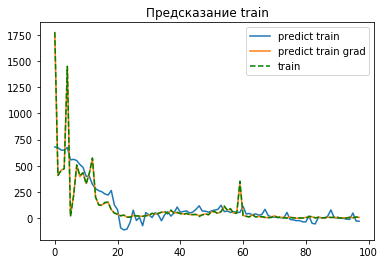

```python
plt.plot(y_pred_t, label='predict train')
plt.plot(y_predg_t, label='predict train grad')
plt.plot(y_train,'--g', label='train')
plt.legend()
plt.title('Предсказание train')
plt.show()
```

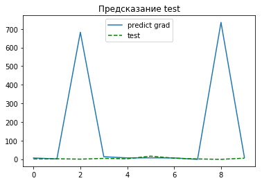

```python
#plt.plot(y_pred, label='predict')
plt.plot(y_predg, label='predict grad')
plt.plot(y_test, '--g',label='test')
plt.legend()
plt.title('Предсказание test')
plt.show()
```

```python
error_p =np.mean(np.abs(y_test.reshape((10))-y_predg.reshape((10))+2)/(y_test+2).reshape((10)))*100

print('error in MAPE :', error_p, '%')
```

```
error in MAPE : 10807.714317558433 %
```

```python
error_mae =np.mean(np.abs(y_test.reshape((10))-y_predg.reshape((10))))

print('error in MAPE :', error_mae, )
```

```
error in MAPE : 145.50691428130398
```

```python
y_test.reshape((10))-y_predg.reshape((10))
```

```
array([  -5.08199986,    0.75801936, -682.53391981,   -9.06243726,
         -4.49585797,    9.0057594 ,   -1.46744016,    2.30228343,
       -736.61558503,   -3.74584053])
```

## Box-Cox преобразование

```python
import scipy.stats as scs
```

```python
def invboxcox(y,lmbda):
    # обрабтное преобразование Бокса-Кокса
    if lmbda == 0:
        return(np.exp(y))
    else:
        return(np.exp(np.log(lmbda*y+1)/lmbda))
```

Текущее число больных

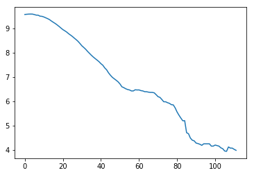

```python
X_dif=XX[23:,3]-XX[23:,4]-XX[23:,5]
X_dif_log, lmbda_dif = scs.boxcox(X_dif+1)
plt.plot(X_dif_log)
plt.show()
```

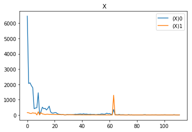

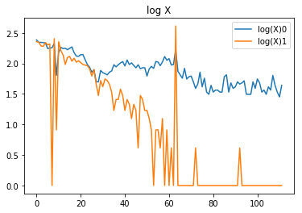

```python
X_log0, lmbda0 = scs.boxcox(XX[23:,0]+10)
X_log1, lmbda1 = scs.boxcox(XX[23:,1]+1)
X_log2, lmbda2 = scs.boxcox(XX[23:,2]+1)

plt.plot(XX[23:,0], label='(X)0')
plt.plot(XX[23:,1], label='(X)1')
#plt.plot(XX[23:,2], label='(X)2')
plt.legend()
plt.title(' X')
plt.show()

plt.plot(X_log0[:], label='log(X)0')
plt.plot(X_log1[:], label='log(X)1')
#plt.plot(X_log2[:], label='log(X)2')
plt.legend()
plt.title('log X')
plt.show()
```

Соберем из Логарифмированных признаков новую модель

```python
X_log = np.concatenate([X_log0.reshape((X_log0.shape[0],1)),(X_log1).reshape((X_log1.shape[0],1))], axis= 1)
X_log = np.concatenate([X_log,(X_log2).reshape((X_log2.shape[0],1))], axis= 1)
X_log = np.concatenate([X_log,(X_dif_log).reshape((X_dif_log.shape[0],1))], axis= 1)

y = X_log[h+p:,0].reshape((X_log0.shape[0]-h-p,1))

X_log_all =[]
for i in range(len(y)):
    xx = X_log[i:i+p,:]
    X_log_all.append(xx.reshape(X_log.shape[1]*p))

    N=-10
X_log_all=np.array(X_log_all)
x_trainl,y_train,x_testl,y_test=X_log_all[:N,:],y[:N,:],X_log_all[N:,:],y[N:,:]

x_trainl.shape
```

```
(98, 12)
```

```python
y_train.shape
```

```
(98, 1)
```

```python
model_lb.fit(x_trainl,y_train)
model_gb.fit(x_trainl,y_train)
```

```
GradientBoostingRegressor(alpha=0.9, ccp_alpha=0.0, criterion='friedman_mse',
                          init=None, learning_rate=0.1, loss='ls', max_depth=3,
                          max_features=None, max_leaf_nodes=None,
                          min_impurity_decrease=0.0, min_impurity_split=None,
                          min_samples_leaf=1, min_samples_split=2,
                          min_weight_fraction_leaf=0.0, n_estimators=100,
                          n_iter_no_change=None, presort='deprecated',
                          random_state=None, subsample=1.0, tol=0.0001,
                          validation_fraction=0.1, verbose=0, warm_start=False)
```

```python
y_pred = model_lb.predict(x_testl)
y_pred_t = model_lb.predict(x_trainl)

y_predg = model_gb.predict(x_testl)
y_predg_t = model_gb.predict(x_trainl)
```

```python
error_ =np.mean(np.abs(y_pred-y_test))
print(error_)

error_ =np.mean(np.abs(y_predg-y_test))
print(error_)
```

```
0.10771440801717855
0.08182361926456609
```

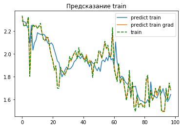

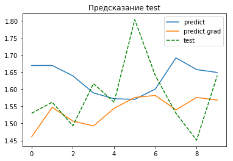

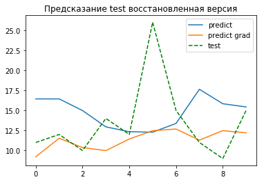

```python
plt.plot(y_pred_t, label='predict train')
plt.plot(y_predg_t, label='predict train grad')
plt.plot(y_train,'--g', label='train')
plt.legend()
plt.title('Предсказание train')
plt.show()
plt.plot(y_pred, label='predict')
plt.plot(y_predg, label='predict grad')
plt.plot(y_test, '--g',label='test')
plt.legend()
plt.title('Предсказание test')
plt.show()

plt.plot(invboxcox(y_pred,lmbda0), label='predict')
plt.plot(invboxcox(y_predg,lmbda0), label='predict grad')
plt.plot(invboxcox(y_test,lmbda0), '--g',label='test')
plt.legend()
plt.title('Предсказание test восстановленная версия')
plt.show()
```

```python
error_p =np.mean(np.abs(invboxcox(y_predg,lmbda0)-invboxcox(y_test,lmbda0))/invboxcox(y_test,lmbda0))*100
print('MAPE :' , error_p)
```

```
MAPE : 20.090416507980148
```

```python
error_p =np.mean(np.abs(invboxcox(y_test[1:],lmbda0)-invboxcox(y_test[:-1],lmbda0))/invboxcox(y_test[:-1],lmbda0))*100
print('MAPE :' , error_p)
```

```
MAPE : 38.948088948088945
```

```python
error_p =np.mean(np.abs(invboxcox(y_test,lmbda0)-np.mean(invboxcox(y_test,lmbda0)))/invboxcox(y_test,lmbda0))*100
print('MAPE :' , error_p)
```

```
MAPE : 22.71028971028973
```

```python
import statsmodels.api as sm
from statsmodels.tsa.arima_model import ARIMA
```

```python
#X_x = X_log_all[:,0]

X_x = X_dif_log[:]
```

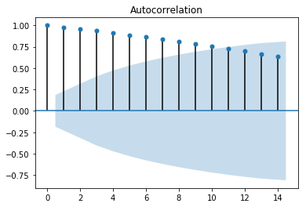

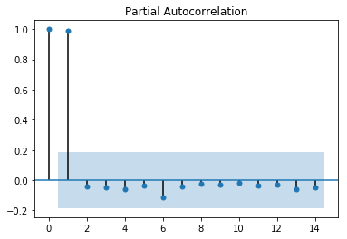

```python
sm.graphics.tsa.plot_acf(X_x, lags=14)
plt.show()
sm.graphics.tsa.plot_pacf(X_x, lags=14)
plt.show()
```

смотримм на PACF - 1-е значение имеет смысл - p=1

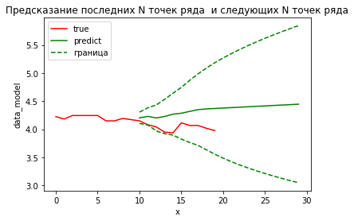

```python
# N=10    # число точек для теста
# строим модель
N = 10

model = ARIMA(X_x[:-N], order=(1, 0,10))
model_fit = model.fit(disp=1)
# делаем оценку старых значений
y_p = model_fit.predict(len(X_x[:-N]), len(X_x[:-N]), typ='levels')
y_f = model_fit.forecast(2*N)
plt.plot(X_x[-10-N:],'r',label ='true')

plt.plot(np.arange(2*N)+N,y_f[0],'g',label ='predict')
plt.plot(np.arange(2*N)+N,y_f[2][:,1],'--g', label = 'граница')
plt.plot(np.arange(2*N)+N,y_f[2][:,0],'--g')
plt.xlabel('x')
plt.ylabel('data_model')
plt.title('Предсказание последних N точек ряда  и следующих N точек ряда')
plt.legend()
plt.show()
```